# {recalc}: Find the bounds of an independent t-test’s p-value and Cohen’s d from M/SD/N

Ian Hussey

27 May 2026

# Dependencies

```r
library(knitr)
library(kableExtra)
# devtools::install_github("ianhussey/recalc")
library(recalc)
```

# Overview

The package exposes three entry points for the independent-samples *t*-test consistency check:

- **`recalc_independent_t_p()`** — *p*-value multiverse only.
- **`recalc_independent_t_d()`** — Cohen’s *d* / Hedges’ *g* and CI multiverse only.
- **`recalc_independent_t()`** — convenience wrapper that calls both and returns the merged result.

Each function takes the reported summary statistics (M, SD, *N* per group), the reporting precision (`m_digits`, `sd_digits`, and `p_digits` / `d_digits`), and a description of the rounding convention. The functions iterate over the analytic choices the user does *not* know — e.g. Student’s vs Welch’s *t*, alternative hypothesis, Hedges correction variant, SE-of-*d* formula — and return the full range of *p* and *d* values that any combination of those choices could have produced.

The output contains both the **unrounded** multiverse bounds (`min_p`, `max_p`, `min_d`, `max_d`) and the **rounded** bounds (`min_p_rounded`, `max_p_rounded`, etc.). The `p_inbounds` / `d_inbounds` flags compare the *reported* value against the **rounded** bounds, so the comparison is apples-to-apples even when the analytic value sits within half a ULP of 0 or 1.

# Recalculate p and d together

The most common workflow: a paper reports M, SD, *N*, a *p*-value, and a Cohen’s *d* with 95% CI. Pass them all to `recalc_independent_t()` and read off whether the reported numbers are consistent with each other.

```r
res <- recalc_independent_t(
  # essential arguments: M / SD / N for the two groups and their reported precision
  m1        = 10.30,
  m2        = 8.71,
  sd1       = 3.12,
  sd2       = 2.80,
  n1        = 50,
  n2        = 48,
  m_digits  = 2,
  sd_digits = 2,
  # rounding mode used by the report. One of:
  #   "either"   (default; half-up or bankers — same closed preimage)
  #   "half_up", "bankers", "truncate"
  rounding  = "either",

  # ---- reported p-value (optional) -------------------------------------
  p          = 0.01,
  p_digits   = 2,
  p_operator = "less_than",       # "equals", "less_than", "greater_than",
                                  # "less_than_or_equal_to", "greater_than_or_equal_to"
  # The set of t-test variants and alternatives the original analyst could
  # plausibly have used. Pass NULL on p_methods to iterate over both
  # Student's pooled and Welch's. Pass a single string on alternative if
  # the paper reports which alternative was used (recommended — see note
  # in the validation simulation about why iterating over all three
  # alternatives produces intervals spanning [0, 1] and is undiagnostic).
  p_methods   = NULL,
  alternative = "two.sided",

  # ---- reported effect size (optional) ---------------------------------
  d           = 0.53,
  d_ci_lower  = 0.20,
  d_ci_upper  = 0.90,
  d_digits    = 2,
  # d-formula variants the original analyst could have used:
  #   "pooled_df"  — sp from df-weighted pooled variance (the usual default)
  #   "pooled_n"   — sp from N-weighted pooled variance
  #   "simple_avg" — sp = sqrt((sd1^2 + sd2^2)/2) (Cohen 1988 original)
  d_formulas        = NULL,         # NULL = all three
  # Hedges' small-sample correction:
  #   "none"   — plain Cohen's d
  #   "approx" — 1 - 3/(4*df - 1)  (standard small-sample approximation)
  #   "exact"  — gamma-based exact correction
  hedges_correction = NULL,         # NULL = all three
  # CI method:
  #   "wald_t"  — d ± qt(.975, df_pooled) × SE(d)
  #   "wald_z"  — d ± qnorm(.975)         × SE(d)
  #   "welch_t" — Wald with Welch df
  #   "nct"     — noncentral-t inversion
  ci_methods        = NULL,         # NULL = all four
  # SE-of-d formula (Wald methods only):
  #   "hedges_olkin"  — sqrt((n1+n2)/(n1*n2) + d^2/(2*(n1+n2)))
  #   "cumming"       — sqrt((n1+n2)/(n1*n2) + d^2/(2*(n1+n2-2)))
  #   "uncorrected"   — sqrt((n1+n2)/(n1*n2))   (drops the d^2 bias term)
  se_formulas       = NULL,         # NULL = all three
  alpha             = 0.05,

  # ---- direction and the SE / SD confusion branch ----------------------
  direction               = "m1_minus_m2",   # or "m2_minus_m1", "both"
  include_se_sd_confusion = FALSE
)
```

## Reproduced summary

The `reproduced` data frame is a one-row summary containing both the unrounded and rounded multiverse bounds for both *p* and *d*, along with the `inbounds` flags that say whether the reported values are consistent with what the multiverse can produce.

```r
res$reproduced |>
  kable() |>
  kable_classic(full_width = FALSE)
```

| d | min_d | max_d | min_d_rounded | max_d_rounded | d_inbounds | p_operator | p | min_p | max_p | min_p_rounded | max_p_rounded | p_inbounds |
| --- | --- | --- | --- | --- | --- | --- | --- | --- | --- | --- | --- | --- |
| 0.53 | 0.5273489 | 0.5406632 | 0.53 | 0.54 | TRUE | less_than | 0.01 | 0.008706 | 0.0099373 | 0.01 | 0.01 | TRUE |

## Multiverse of *p*-values

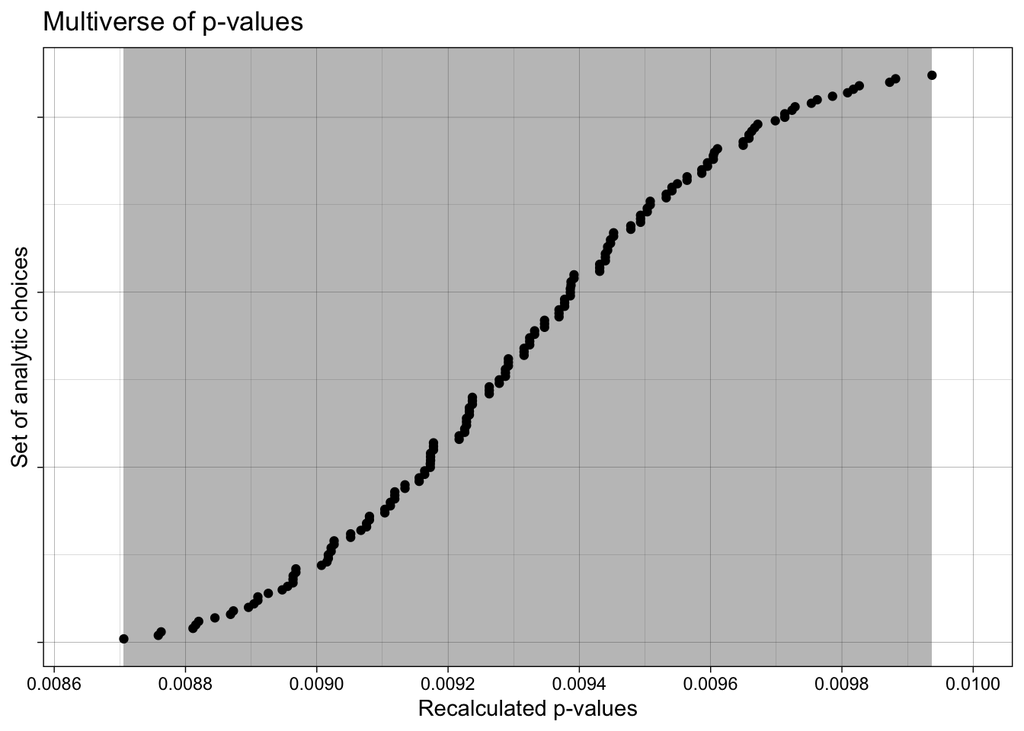

```r
plot_multiverse_p(res)
```

```r
# res$p_results |>
#   head() |>
#   kable() |>
#   kable_classic(full_width = FALSE)
```

## Multiverse of *d* and 95% CIs

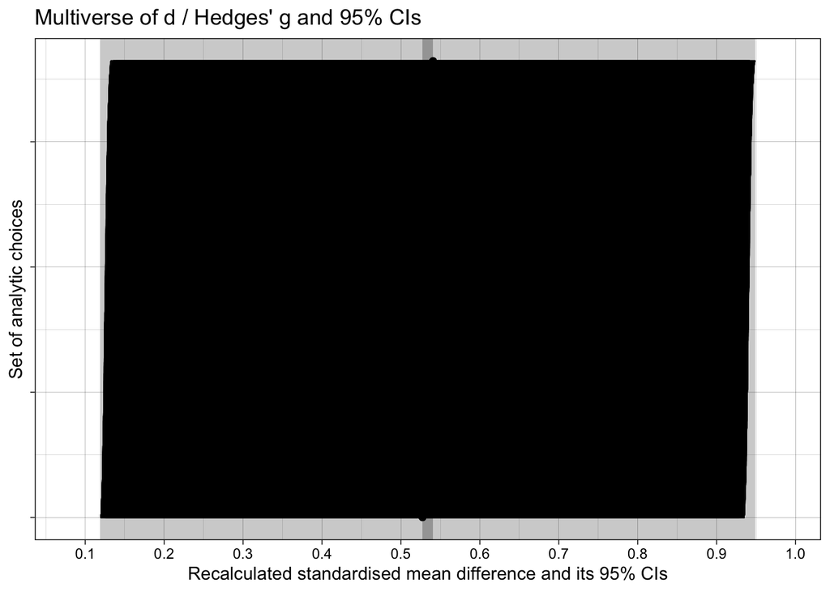

```r
plot_multiverse_d(res)
```

```r
# res$d_results |>
#   head() |>
#   kable() |>
#   kable_classic(full_width = FALSE)
```

# Use only the *p*-value check

If you only have a reported *p* (or only care about *p*), use the focused entry point. It avoids enumerating the (often much larger) *d*-multiverse and gives you a smaller result list.

```r
res_p <- recalc_independent_t_p(
  m1 = 10.30, m2 = 8.71, sd1 = 3.12, sd2 = 2.80, n1 = 50, n2 = 48,
  m_digits = 2, sd_digits = 2,
  p = 0.01, p_digits = 2, p_operator = "less_than",
  rounding     = "either",
  p_methods    = NULL,            # both Student's and Welch's
  alternative  = "two.sided"      # what the paper says
)

res_p$reproduced |>
  kable() |>
  kable_classic(full_width = FALSE)
```

| p_operator | p | min_p | max_p | min_p_rounded | max_p_rounded | p_inbounds |
| --- | --- | --- | --- | --- | --- | --- |
| less_than | 0.01 | 0.008706 | 0.0099373 | 0.01 | 0.01 | TRUE |

# Use only the *d* check

Symmetrically, when the paper reports an effect size but no *p*, or you only care about whether the reported *d* is in the SMD multiverse.

```r
res_d <- recalc_independent_t_d(
  m1 = 10.30, m2 = 8.71, sd1 = 3.12, sd2 = 2.80, n1 = 50, n2 = 48,
  m_digits = 2, sd_digits = 2,
  d = 0.53, d_ci_lower = 0.20, d_ci_upper = 0.90, d_digits = 2,
  rounding          = "either",
  d_formulas        = NULL,
  hedges_correction = NULL,
  ci_methods        = NULL,
  se_formulas       = NULL,
  alpha             = 0.05,
  direction         = "m1_minus_m2"
)

res_d$reproduced |>
  kable() |>
  kable_classic(full_width = FALSE)
```

| d | min_d | max_d | min_d_rounded | max_d_rounded | d_inbounds |
| --- | --- | --- | --- | --- | --- |
| 0.53 | 0.5273489 | 0.5406632 | 0.53 | 0.54 | TRUE |

# Narrowing the multiverse

Each axis the user knows from the report can be passed as a single string to tighten the interval. For example, if the paper explicitly says it used a Welch *t*-test, two-sided, with half-up rounding throughout:

```r
res_narrow <- recalc_independent_t_p(
  m1 = 10.30, m2 = 8.71, sd1 = 3.12, sd2 = 2.80, n1 = 50, n2 = 48,
  m_digits = 2, sd_digits = 2,
  p = 0.01, p_digits = 2, p_operator = "less_than",
  rounding    = "half_up",        # the actual reporting convention
  p_methods   = "welch_t",        # the actual test used
  alternative = "two.sided"       # the actual alternative
)

res_narrow$reproduced |>
  kable() |>
  kable_classic(full_width = FALSE)
```

| p_operator | p | min_p | max_p | min_p_rounded | max_p_rounded | p_inbounds |
| --- | --- | --- | --- | --- | --- | --- |
| less_than | 0.01 | 0.008706 | 0.0097857 | 0.01 | 0.01 | TRUE |

Each constraint narrows the multiverse and makes any inconsistency easier to detect; conversely, when the report doesn’t disclose one of these choices, leaving the corresponding argument at its default (or `NULL`) widens the interval to cover all of the choices the analyst could have made.

# Notes on rounding modes

`rounding = "either"` (the default) covers the symmetric half-up / bankers preimage (`[value − ½ULP, value + ½ULP]`), which is what most journals use. If the report instead **truncates** (e.g. `M = 3.1` for an actual mean of 3.18), pass `rounding = "truncate"` explicitly — `"either"` does not cover truncated reports and will produce false-positive inconsistency flags on them. See the validation simulation for a quantitative breakdown.

# Direction of effect and SE / SD confusion

The package exposes two further axes that are not enabled by default:

- `direction = "both"` iterates over M1 − M2 and M2 − M1, useful when the report’s sign convention is unclear.
- `include_se_sd_confusion = TRUE` adds a branch where the reported “SDs” are reinterpreted as misreported SEs (`SD = SE × sqrt(n)`). This is a known reporting error in some literatures; enabling the branch lets you check whether the reported numbers become consistent under that interpretation.

Both widen the multiverse and should only be enabled when you have specific reason to consider them.